# Practical Machine Learning Final Project

Jackson Corley

12/6/2019

# **Overview**

## Background

Using devices such as Jawbone Up, Nike FuelBand, and Fitbit it is now possible to collect a large amount of data about personal activity relatively inexpensively. These type of devices are part of the quantified self movement – a group of enthusiasts who take measurements about themselves regularly to improve their health, to find patterns in their behavior, or because they are tech geeks. One thing that people regularly do is quantify how much of a particular activity they do, but they rarely quantify how well they do it. In this project, your goal will be to use data from accelerometers on the belt, forearm, arm, and dumbell of 6 participants. They were asked to perform barbell lifts correctly and incorrectly in 5 different ways. More information is available from the website here: http://groupware.les.inf.puc-rio.br/har (see the section on the Weight Lifting Exercise Dataset).

## Data Set

The training data for this project are available here: https://d396qusza40orc.cloudfront.net/predmachlearn/pml-training.csv

The test data are available here: https://d396qusza40orc.cloudfront.net/predmachlearn/pml-testing.csv

The data sets above were taken from http://groupware.les.inf.puc-rio.br/har courtesy of Ugulino, W.; Cardador, D.; Vega, K.; Velloso, E.; Milidiu, R.; Fuks, H. Wearable Computing: Accelerometers’ Data Classification of Body Postures and Movements.

## Objective

The goal of your project is to predict the manner in which they did the exercise. This is the “classe” variable in the training set. You may use any of the other variables to predict with. You should create a report describing how you built your model, how you used cross validation, what you think the expected out of sample error is, and why you made the choices you did. You will also use your prediction model to predict 20 different test cases.

# **Loading & Cleaning Data**

```r
rm(list=ls())
library(caret)
```

```r
library(ggplot2)
library(rpart)
library(rpart.plot)
library(RColorBrewer)
library(knitr)
library(rattle)
library(randomForest)
library(corrplot)
library(gbm)
library(dplyr)
# install.packages("e1071")
```

## Get data from URL. Remove the first 7 variables since they will not be used for prediction

```r
trainUrl <- "http://d396qusza40orc.cloudfront.net/predmachlearn/pml-training.csv"
validUrl <- "http://d396qusza40orc.cloudfront.net/predmachlearn/pml-testing.csv"
train_data <- read.csv(url(trainUrl))
valid_data <- read.csv(url(validUrl))
train_data <- train_data[, colSums(is.na(train_data)) == 0]
valid_data <- valid_data[, colSums(is.na(valid_data)) == 0]
train_data <- train_data[, -c(1:7)]
valid_data <- valid_data[, -c(1:7)]
dim(train_data); dim(valid_data)
```

```
## [1] 19622    86
```

```
## [1] 20 53
```

```r
set.seed(12345)
inTrain <- createDataPartition(train_data$classe, p = 0.7, list = FALSE)
train_data <- train_data[inTrain,]
test_Data <- train_data[-inTrain,]
NZV <- nearZeroVar(train_data)
train_data <- train_data[, -NZV]
test_Data  <- test_Data[, -NZV]
dim(train_data); dim(valid_data); dim(test_Data)
```

```
## [1] 13737    53
```

```
## [1] 20 53
```

```
## [1] 4140   53
```

# **Exploring Data**

## Using corrplot correlated predictors are denoted by darker colors.

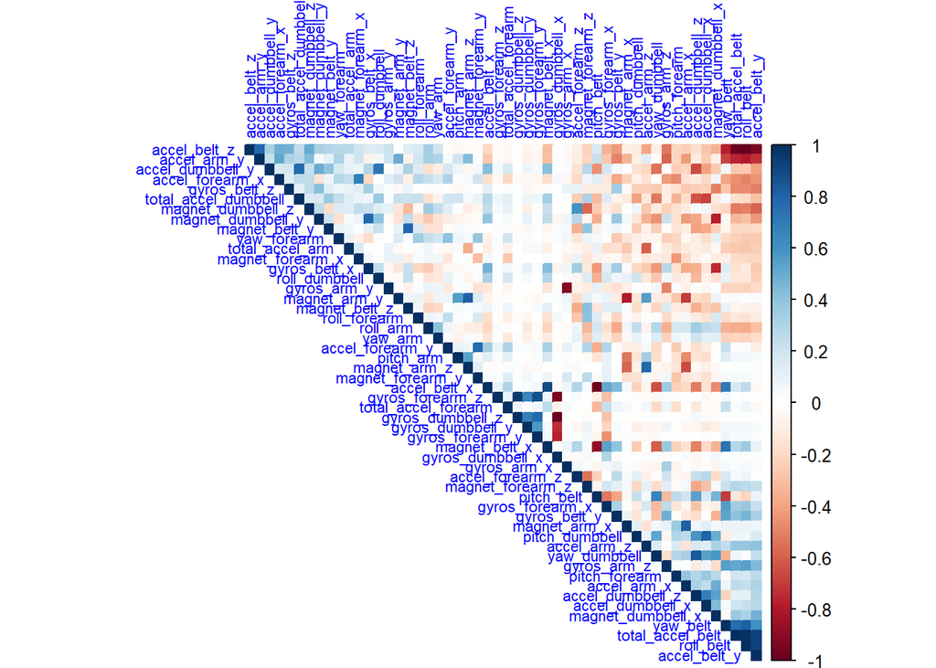

```r
corr_matr <- cor(train_data[, -53])
corrplot(corr_matr, order = "FPC", method = "color", type = "upper",
         tl.cex = 0.7, tl.col = rgb(0, 0, 1))
```

```r
str_corr = findCorrelation(corr_matr, cutoff=0.75)
names(train_data)[str_corr]
```

```
##  [1] "accel_belt_z"      "roll_belt"         "accel_belt_y"
##  [4] "accel_arm_y"       "total_accel_belt"  "accel_dumbbell_z"
##  [7] "accel_belt_x"      "pitch_belt"        "magnet_dumbbell_x"
## [10] "accel_dumbbell_y"  "magnet_dumbbell_y" "accel_dumbbell_x"
## [13] "accel_arm_x"       "accel_arm_z"       "magnet_arm_y"
## [16] "magnet_belt_z"     "accel_forearm_y"   "gyros_forearm_y"
## [19] "gyros_dumbbell_x"  "gyros_dumbbell_z"  "gyros_arm_x"
```

# **Model Development**

## classification Trees

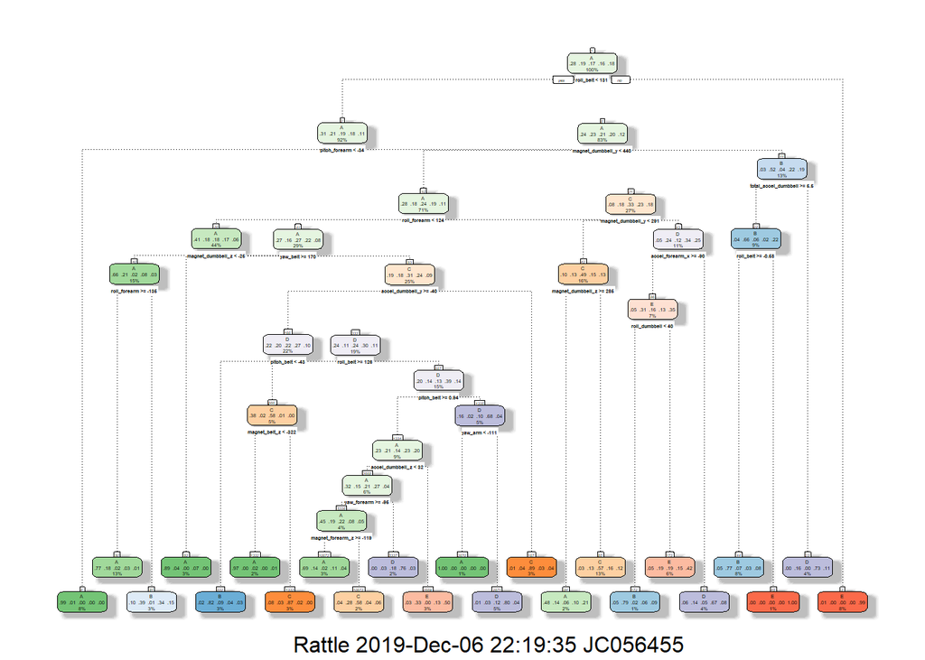

```r
set.seed(12345)
class_tree_M1 <- rpart(classe ~ ., data=train_data, method="class")
fancyRpartPlot(class_tree_M1)
```

```r
pred_tree_M1 <- predict(class_tree_M1, test_Data, type = "class")
cm_tree <- confusionMatrix(pred_tree_M1, test_Data$classe)
cm_tree
```

```
## Confusion Matrix and Statistics
##
##           Reference
## Prediction    A    B    C    D    E
##          A 1086  134   12   46   28
##          B   30  438   40   42   54
##          C   27  103  589  106   81
##          D   11   53   43  406   40
##          E   18   70   39   53  591
##
## Overall Statistics
##
##                Accuracy : 0.7512
##                  95% CI : (0.7377, 0.7643)
##     No Information Rate : 0.2831
##     P-Value [Acc > NIR] : < 2.2e-16
##
##                   Kappa : 0.6841
##
##  Mcnemar's Test P-Value : < 2.2e-16
##
## Statistics by Class:
##
##                      Class: A Class: B Class: C Class: D Class: E
## Sensitivity            0.9266   0.5489   0.8147  0.62175   0.7443
## Specificity            0.9259   0.9503   0.9072  0.95784   0.9462
## Pos Pred Value         0.8315   0.7252   0.6501  0.73418   0.7665
## Neg Pred Value         0.9697   0.8982   0.9586  0.93114   0.9397
## Prevalence             0.2831   0.1928   0.1746  0.15773   0.1918
## Detection Rate         0.2623   0.1058   0.1423  0.09807   0.1428
## Detection Prevalence   0.3155   0.1459   0.2188  0.13357   0.1862
## Balanced Accuracy      0.9262   0.7496   0.8609  0.78979   0.8453
```

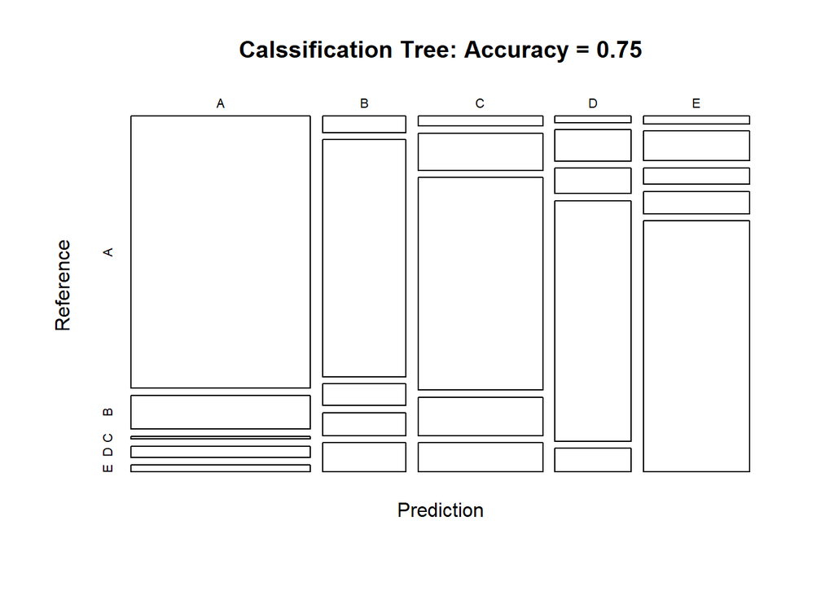

```r
plot(cm_tree$table, col = cm_tree$byClass,
     main = paste("Calssification Tree: Accuracy =", round(cm_tree$overall['Accuracy'], 2)))
```

## Random Forest

```r
set.seed(12345)
rand_forst_cont <- trainControl(method="cv", number=3, verboseIter=FALSE)
rand_forst_M1 <- train(classe ~ ., data=train_data, method="rf", trControl=rand_forst_cont)

rand_forst_pred <- predict(rand_forst_M1, newdata=test_Data)
cm_rand_forst <- confusionMatrix(rand_forst_pred, test_Data$classe)
cm_rand_forst
```

```
## Confusion Matrix and Statistics
##
##           Reference
## Prediction    A    B    C    D    E
##          A 1172    0    0    0    0
##          B    0  798    0    0    0
##          C    0    0  723    0    0
##          D    0    0    0  653    0
##          E    0    0    0    0  794
##
## Overall Statistics
##
##                Accuracy : 1
##                  95% CI : (0.9991, 1)
##     No Information Rate : 0.2831
##     P-Value [Acc > NIR] : < 2.2e-16
##
##                   Kappa : 1
##
##  Mcnemar's Test P-Value : NA
##
## Statistics by Class:
##
##                      Class: A Class: B Class: C Class: D Class: E
## Sensitivity            1.0000   1.0000   1.0000   1.0000   1.0000
## Specificity            1.0000   1.0000   1.0000   1.0000   1.0000
## Pos Pred Value         1.0000   1.0000   1.0000   1.0000   1.0000
## Neg Pred Value         1.0000   1.0000   1.0000   1.0000   1.0000
## Prevalence             0.2831   0.1928   0.1746   0.1577   0.1918
## Detection Rate         0.2831   0.1928   0.1746   0.1577   0.1918
## Detection Prevalence   0.2831   0.1928   0.1746   0.1577   0.1918
## Balanced Accuracy      1.0000   1.0000   1.0000   1.0000   1.0000
```

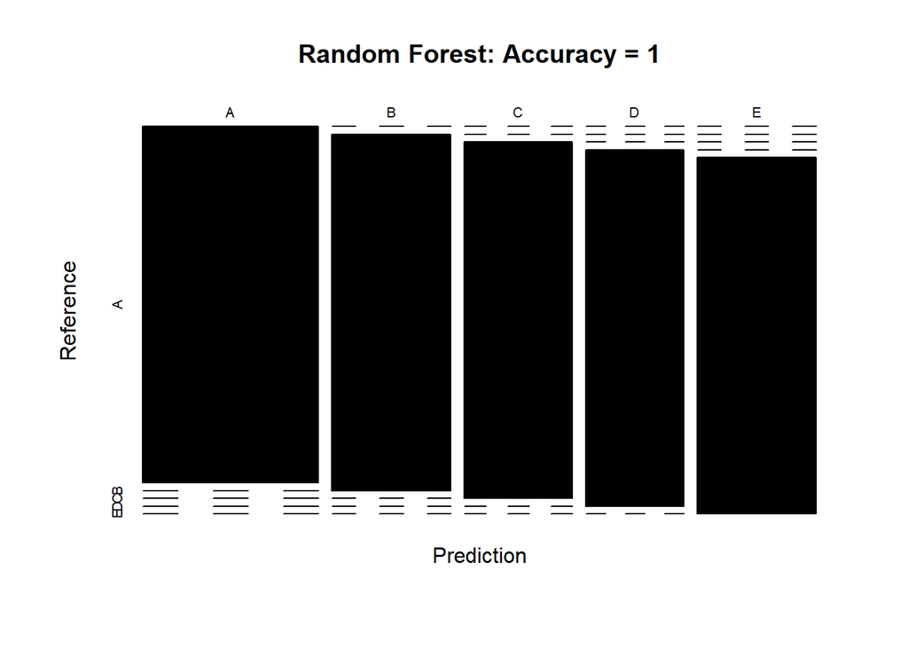

```r
plot(cm_rand_forst$table, col = cm_rand_forst$byClass, main = paste("Random Forest: Accuracy =", round(cm_rand_forst$overall['Accuracy'], 2)))
```

## Generalized Boosting

```r
set.seed(12345)
gen_boost_ctrl <- trainControl(method = "repeatedcv", number = 5, repeats = 1)
gen_boost_M1  <- train(classe ~ ., data=train_data, method = "gbm", trControl = gen_boost_ctrl, verbose = FALSE)
gen_boost_pred <- predict(gen_boost_M1, newdata=test_Data)
cm_gen_boost <- confusionMatrix(gen_boost_pred, test_Data$classe)
cm_gen_boost
```

```
## Confusion Matrix and Statistics
##
##           Reference
## Prediction    A    B    C    D    E
##          A 1164   15    0    1    1
##          B    8  771   20    1    6
##          C    0   11  699   24    3
##          D    0    0    4  625    6
##          E    0    1    0    2  778
##
## Overall Statistics
##
##                Accuracy : 0.9751
##                  95% CI : (0.9699, 0.9796)
##     No Information Rate : 0.2831
##     P-Value [Acc > NIR] : < 2.2e-16
##
##                   Kappa : 0.9685
##
##  Mcnemar's Test P-Value : NA
##
## Statistics by Class:
##
##                      Class: A Class: B Class: C Class: D Class: E
## Sensitivity            0.9932   0.9662   0.9668   0.9571   0.9798
## Specificity            0.9943   0.9895   0.9889   0.9971   0.9991
## Pos Pred Value         0.9856   0.9566   0.9484   0.9843   0.9962
## Neg Pred Value         0.9973   0.9919   0.9929   0.9920   0.9952
## Prevalence             0.2831   0.1928   0.1746   0.1577   0.1918
## Detection Rate         0.2812   0.1862   0.1688   0.1510   0.1879
## Detection Prevalence   0.2853   0.1947   0.1780   0.1534   0.1886
## Balanced Accuracy      0.9937   0.9778   0.9778   0.9771   0.9895
```

## Model Comparison

The accuracies of teh models are as follows:

- Classification Trees - 0.75
- Random Forest - 1
- Genralized Boosting - 0.98

# **Prediction**

```r
Results <- predict(rand_forst_M1, newdata=valid_data)
Results
```

```
##  [1] B A B A A E D B A A B C B A E E A B B B
## Levels: A B C D E
```